# Health Equity Though Breast Cancer Patient Data

Lilith Appel, Jacob Posner, Mateo Useche

2024-05-02

# Introduction

Exploring hospital access and healthcare equality through breast cancer patients.

## Background

Healthcare accessibility and quality of care are not uniformly distributed in the United States, with different demographics experiencing discrepancies in their health outcomes. Furthermore, factors like race, gender, and socioeconomic status can exacerbate existing disparities regarding patient outcomes. For instance, Dubay and Lebrun (2012) find that Black and Hispanic people have worse health outcomes compared to white people in the same socioeconomic status. Therefore, it is important to extend the conversation to what other factors contribute to healthcare inequities in the United States.

A serious concern, in the United States, is why women with different demographic backgrounds have such stark differences between their diagnoses. Mootz et al., (2020) find that women with lower socioeconomic status and being uninsured are associated with higher mortality rates. Our paper wants to expand what is currently known about women’s breast cancer diagnoses and focus on additional potential factors that could influence a patient’s correct diagnosis within 90 days of a doctor’s visit. Therefore, we ask, among patients who were diagnosed with breast cancer from 2015-2018, what parameters affect whether or not a breast cancer patient was diagnosed within 90 days of their first hospital visit.

## Motivation

We are motivated to look into this because health accessibility has a huge impact on people’s lives, and investigating possible inequalities will hopefully lead to more equitable healthcare.

# Data Background

For this analysis, we used two different datasets that contained information at either the patient level or the hospital level:

- Health Verity (HV) Dataset
  - Healthcare-related ecosystem specifically for U.S. data
  - Created by a Kaggle challenge containing multiple data sets including health predictors, demographics, socioeconomic status, and zip codes
  - Has patient-level data for individuals who were diagnosed with metastatic triple-negative breast cancers
  - Breast cancer diagnosis with 90 days as “1” yes or “0” no
- Hospital Dataset
  - Contains data from all 50 U.S. states and territories
  - Geocoded and licensed by the U.S. Government Works

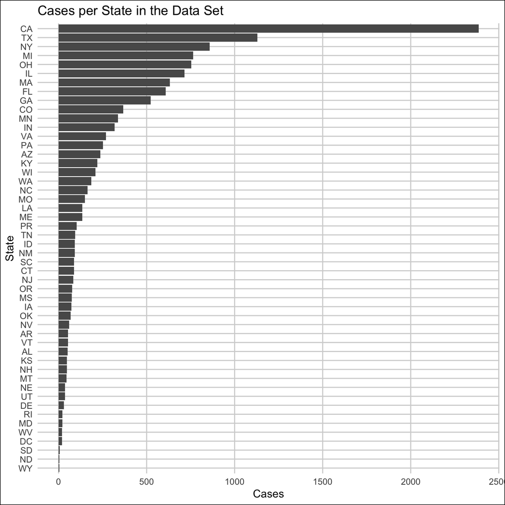

Our main outcome of interest is whether or not a patient got diagnosed with breast cancer within the first 90 days of their hospital visit, and we will use our 76 predictors to see what factors influence our dependent variable the most.

# Data Visualization

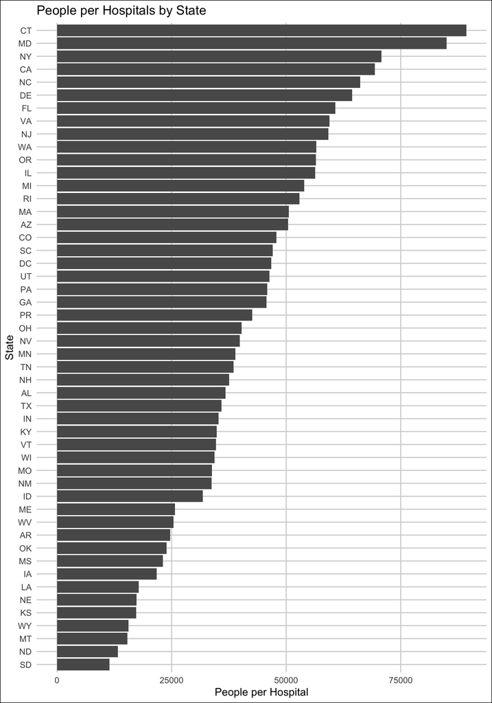

Connecticut and Maryland have the most people per hospital which means that there is limited hospital access in those states.

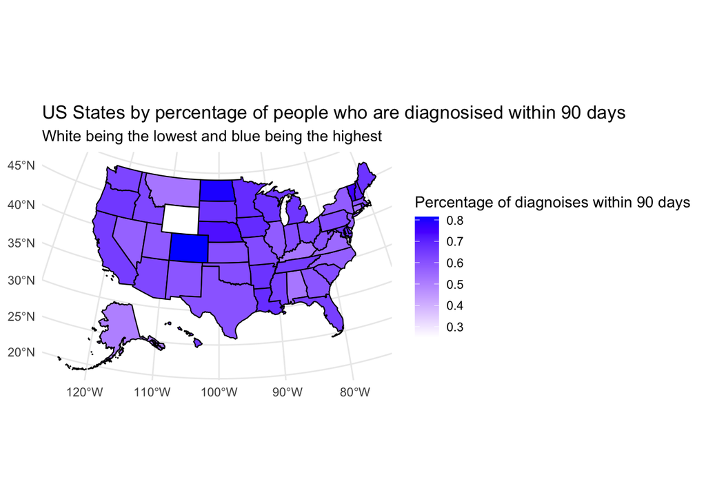

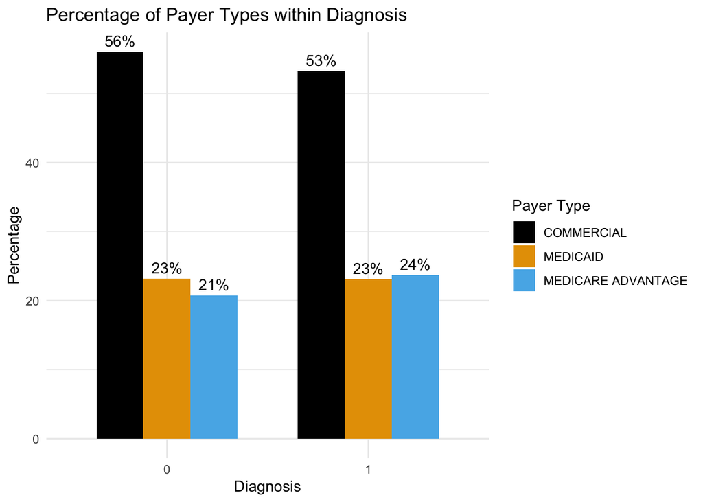

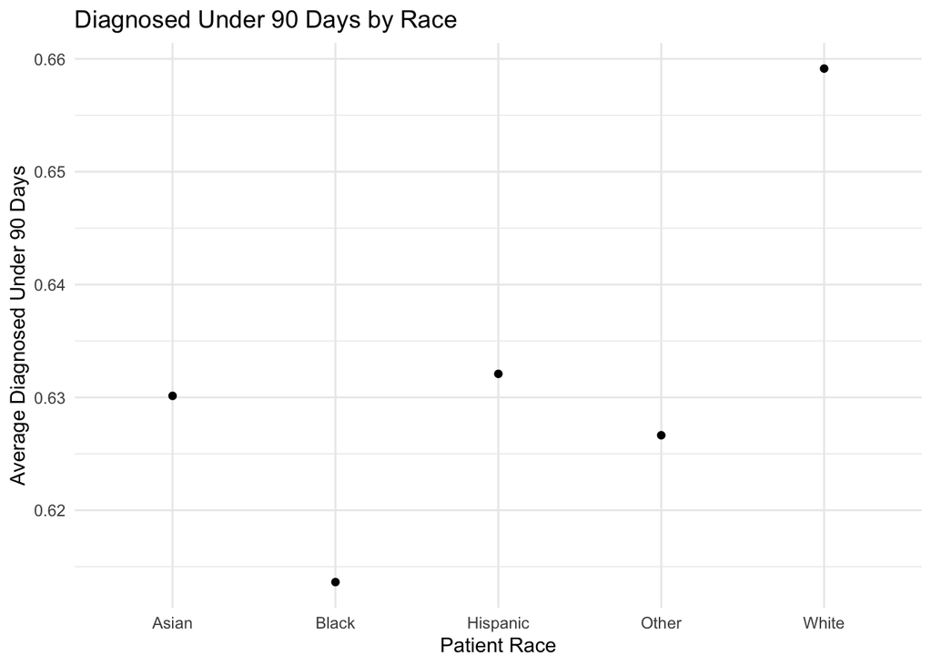

While the averages are somewhat close, we notice that white people get diagnosed within 90 days more than any other race while black people are diagnosed before 90 days at lower rates.

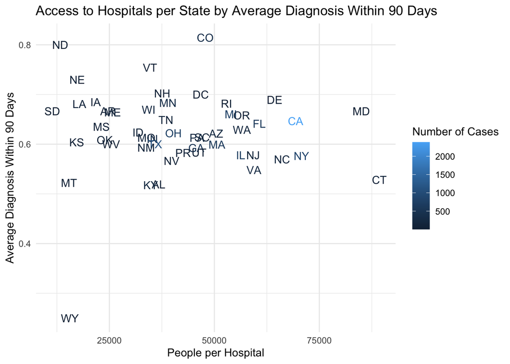

While there are several outliers due to data limitations, we notice that California and New York, which have less hospital access than other states and around average success rates, have a large number of cases in the dataset.

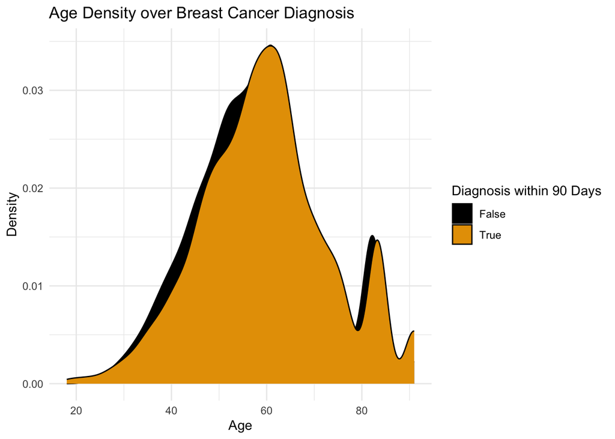

We see that people around age 60 are more likely to have breast cancer and then there is another smaller spike at around at around 82. However, there isn’t really a difference between a diagnosis within 90 days and age.

# Methodology

## Preliminary Model

We began with initial data visualization highlighting the relationship between various predictors of interest in a diagnosis within 90 days of the first hospital visit. From these visualizations, we found that 4 predictors impacted a patient’s diagnosis:

- Type of Insurance
- Race
- Age
- State

Since these variables seemed relevant in our raw data, we included them in our Bayesian Model. Our model assumes that our data follows a Bernoulli Distribution, which aligns with the binary nature of our dependent variable – whether or not a patient was diagnosed within 90 days of their first hospital visit. Our priors take the form of weakly informative priors which is the default in Rstan, meaning that since we do not have actual background information to include in our model, we take the default.

- $\beta_{c0}$
- $\beta_1$
- $\beta_2$
- $\beta_3$
- $\beta_4$

$$\begin{array}{lrll}
\text{Data: } & Y_i | \beta_0, \beta_1,\beta_2,\beta_3,\beta_4 &
\stackrel{ind}{\sim} \text{Bern}(\pi_i) & \text{where }
\log\left(\frac{\pi_i}{1 - \pi_i}\right) = \beta_0 + \beta_1X_{1i} +
\beta_2X_{2i} + ... + \beta_4 X_{4i} \\
&&& \text{equivalently, } \frac{\pi_i}{1 - \pi_i} =
e^{\beta_0 + \beta_1X_{1i} + \beta_2X_{2i} + ... + \beta_4 X_{4i}} \;
\text{ and } \pi_i = \frac{e^{\beta_0 + \beta_1X_{1i} + \beta_2X_{2i} +
... + \beta_4 X_{4i}}}{e^{\beta_0 + \beta_1X_{1i} + \beta_2X_{2i} + ...
+ \beta_4 X_{4i}} + 1} \\
&&& \\
\text{Priors: }
& \beta_{0c} & \sim N(m_0, s_0^2) \\
& \beta_1 & \sim N(m_1, s_1^2) \\
& \beta_2 & \sim N(m_2, s_2^2) \\
& \beta_3 & \sim N(m_3, s_3^2) \\
& \beta_4 & \sim N(m_4, s_4^2) \\
\end{array}$$

### Preliminary Analysis

##Please do not run this model, and instead download “diag_post3.rds” from our GitHub as this model takes ~30 minutes to run

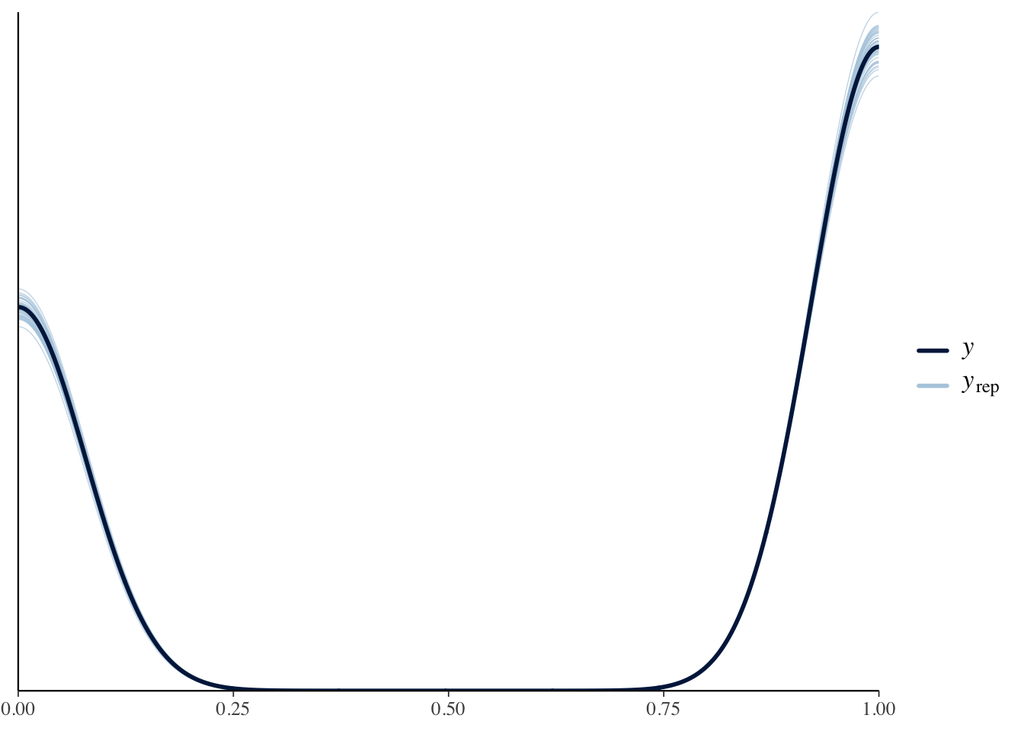

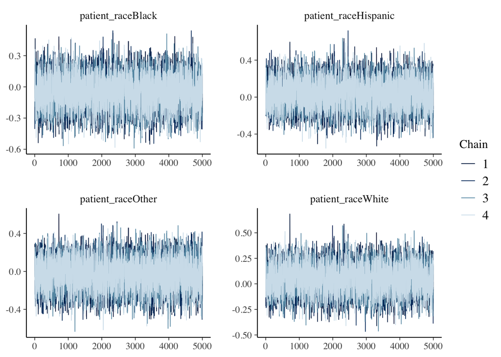

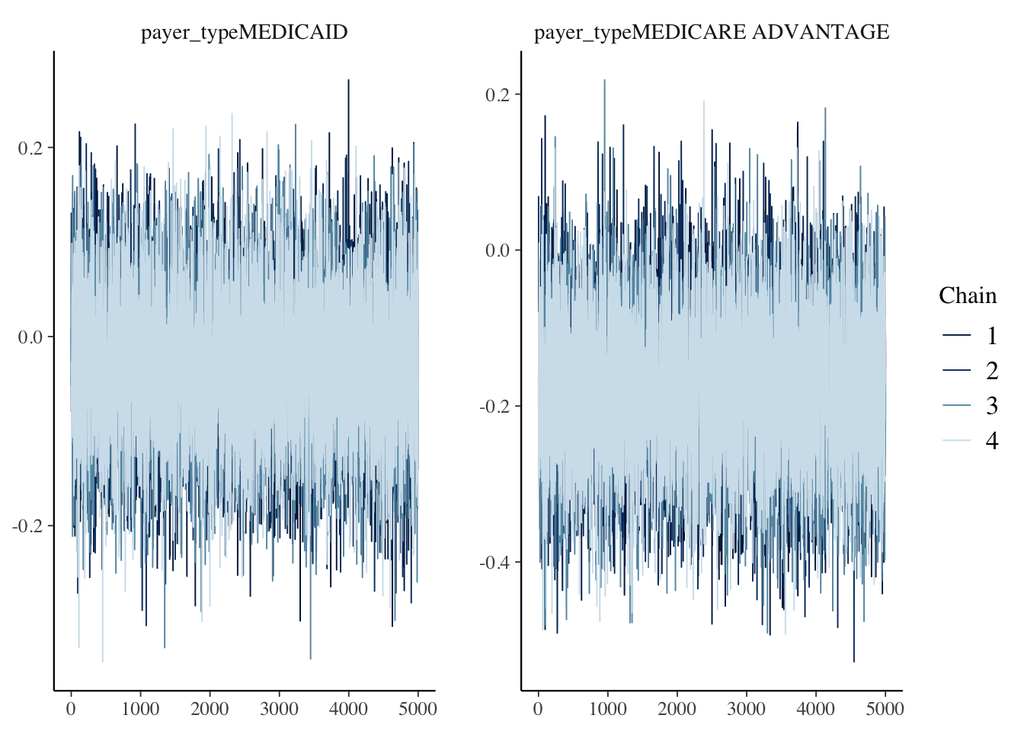

When we look at the traceplots for our various predictors we see random patterns which is what we want. There are no places where the chains get stuck or seem to follow a trend.

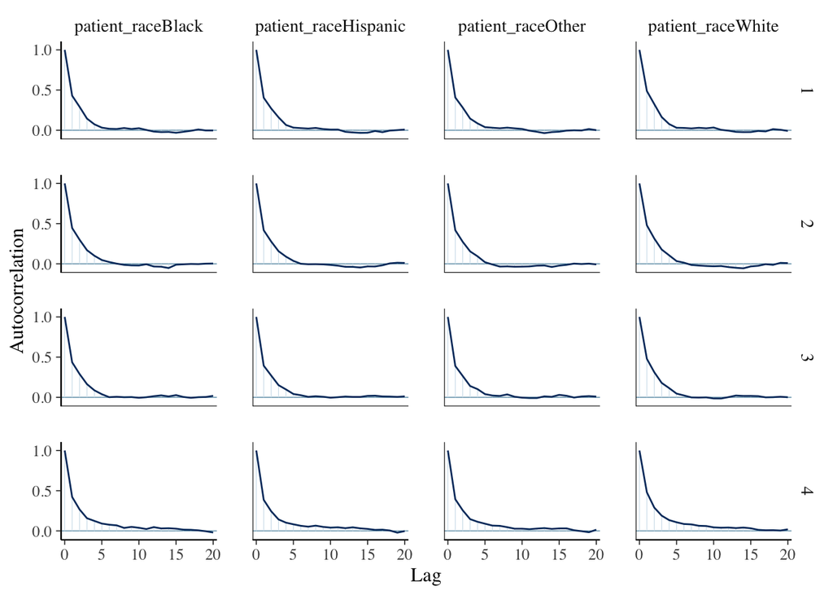

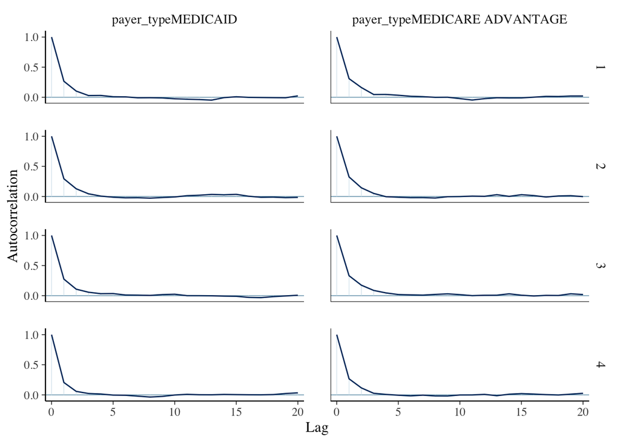

The autocorrelation plots tell us that for this model our chains drop down to no correlation quickly. This is a necessary assumption for us to believe that the chains and samples are random.

# Error Metrics

```
## $confusion_matrix
##  y  0    1
##  0 65 1940
##  1 54 3311
##
## $accuracy_rates
##
## sensitivity      0.98395245
## specificity      0.03241895
## overall_accuracy 0.62867784
```

Our model has 98.4% sensitivity which means it is very good at giving true positives. In the context of this project, it means it correctly classified patients who were diagnosed with breast cancer within 90 days of their first hospital visit. However, specificity is very low with almost zero which means it was very bad at giving a true negative. This means our model was inaccurate at correctly classifying patients who were not diagnosed with cancer within 90 days of their first hospital visit. Our overall accuracy is 62.9%. Since we did not use cross-validation, we expect our model to do worse in a new dataset and have these measures decrease. We did not use cross-validation because we wanted to construct a basic model to understand our existing dataset. We did not care too much about the model’s ability to predict correctly in a new environment.

# Analysis

```
## # A tibble: 52 × 5
##    term                 estimate std.error conf.low conf.high
##    <chr>                   <dbl>     <dbl>    <dbl>     <dbl>
##  1 (Intercept)           -0.685      1.05   -2.40       1.04
##  2 patient_raceBlack     -0.0487     0.146  -0.289      0.194
##  3 patient_raceHispanic   0.0316     0.148  -0.210      0.281
##  4 patient_raceOther     -0.0351     0.154  -0.287      0.220
##  5 patient_raceWhite      0.0474     0.132  -0.171      0.266
##  6 patient_stateAR        1.40       1.11   -0.442      3.24
##  7 patient_stateAZ        0.331      1.04   -1.38       2.04
##  8 patient_stateCA        0.537      1.02   -1.14       2.24
##  9 patient_stateCO        1.65       1.05   -0.0772     3.40
## 10 patient_stateCT      124.       108.     12.4      357.
## # ℹ 42 more rows
```

```
## [1] 1.048516
## [1] 0.9524973
## [1] 0.969335
## [1] 0.8392203
```

The baseline or the intercept is An Asian patient with Private Insurance and living in Alabama.

The odds of being diagnosed within the first 90 days of a hospital visit increase by approximately 4.85% if you are white compared to if you are Asian holding state, age, and type of insurance constant.

The odds of being diagnosed within the first 90 days of a hospital visit decrease by approximately 4.75% if you are Black compared to if you are Asian, holding state, age, and type of insurance constant.

The odds of being diagnosed within the first 90 days of a hospital visit decrease by approximately 16.1% if you have Medicare Advantage Insurance compared to if you have Private Insurance, holding race, age, and state constant.

These relationships are very complex and cannot be taken lightly; therefore, I want to caution you to take these estimates as absolutes. There is a reason that this is the preliminary model and only a stepping-off point. However, it is important to see how even in a basic model we see how much factors like race and insurance play a role in a correct diagnosis.

We began our analysis of the dataset through a simple Bayesian logistic model. Before we did anything too complex, we thought it would be good to construct a model that, intuitively, made sense to us. For example, we asked ourselves the question: what factors play the biggest role in a correct diagnosis of breast cancer? Then we decided to incorporate some predictors we thought could influence diagnosis from our prior knowledge, like race and type of insurance. Overall, our preliminary model helped inform us that our intuition for variables that affect diagnosis was on the right track. It can serve as a check for when we construct a Bayesian model that penalizes insignificant variables, but we might think they provide necessary information.

## Laplace Model

Initially, we aimed to employ a lasso model. However, this required our model’s likelihood to be normal, which was incompatible with the binomial nature of our data, given that we are dealing with a binary outcome variable. Instead, we use a Laplace prior, with mean mu zero, and lambda standard deviation. Which for the purposes of our model, assumes that most predictors will be zero, and the rest will be distributed around zero. In terms of picking lambda, the autoscale function in stan_glm takes care of it, this means that it will adjust the scales of the priors according to the dispersion in the variables.

This model takes in every variable and then tries to minimize the RSS (residual sum of squares), which it does by pushing some variables it deems unimportant to near zero. This is appropriate, as we wanted to use it to see what variables were important for predicting breast cancer diagnosis. It also has full power on the priors of our predictors, which means that we do not have control as users. This is appropriate as we have not researched previous studies on this topic and have no prior beliefs.

In our specific case, this Laplace will try and predict diagnosis within 90 days by using every other predictor and will push predictors it finds as “less important” to zero, to try and allow us to see what predictors are seen as impactful.

$$\begin{array}{lrll}
\text{Data: } & Y_i | \beta_0, \beta_1 X_{1i},...\beta_{75}X_{75i}
& \stackrel{ind}{\sim} \text{Bern}(\pi_i) & \text{where }
\log\left(\frac{\pi_i}{1 - \pi_i}\right) = \beta_0 + \beta_1 X_i ... +
\beta_{75}X_{75i} \\
&&& \text{equivalently, } \frac{\pi_i}{1 - \pi_i} =
e^{\beta_0 + \beta_1 X_i + \beta_{75}X_{75i}} \; \text{ and } \pi_i =
\frac{e^{\beta_0 + \beta_1 X_i ... + \beta_{75} X_{75i}}}{e^{\beta_0 +
\beta_1 X_i ... + \beta_{75} X_{75i}} + 1} \\
&&& \\
\text{Priors: }
& \beta_{0c} & \sim N(m_0, s_0^2) \\
& \beta_1 & \sim \text{Laplace}(m_1, s_1^2) \\
& ... \\
& \beta_{75} & \sim \text{Laplace}(m_{75}, s_{75}^2)\\
\end{array}$$

### Laplace Analysis

These variables, are originally characters in the dataset but are numeric variables

The dataset had blank values, which R is not treating as equal to an NA

- We originally wanted to use a lasso prior to auto filtering our data
  - After analysis, we noticed it required a normal likelihood, but our data is binomial
- Switched to a Laplace prior
  - Assumes variables will be zero,
  - Pushed a lot of the original 75 variables to zero while keeping some important predictors

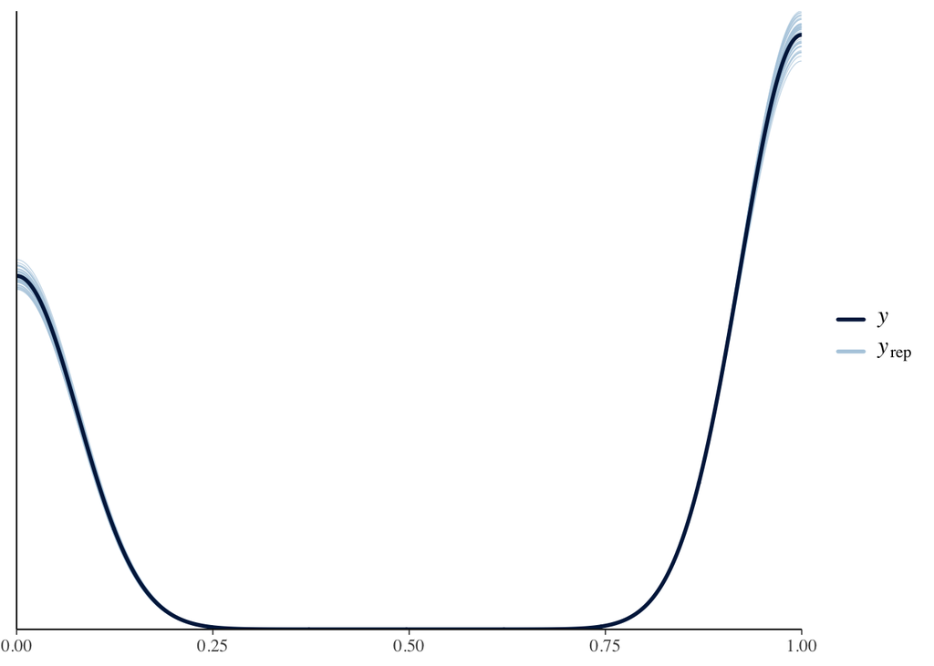

Using the pp_check we see that our possible models created by our model follow the data.

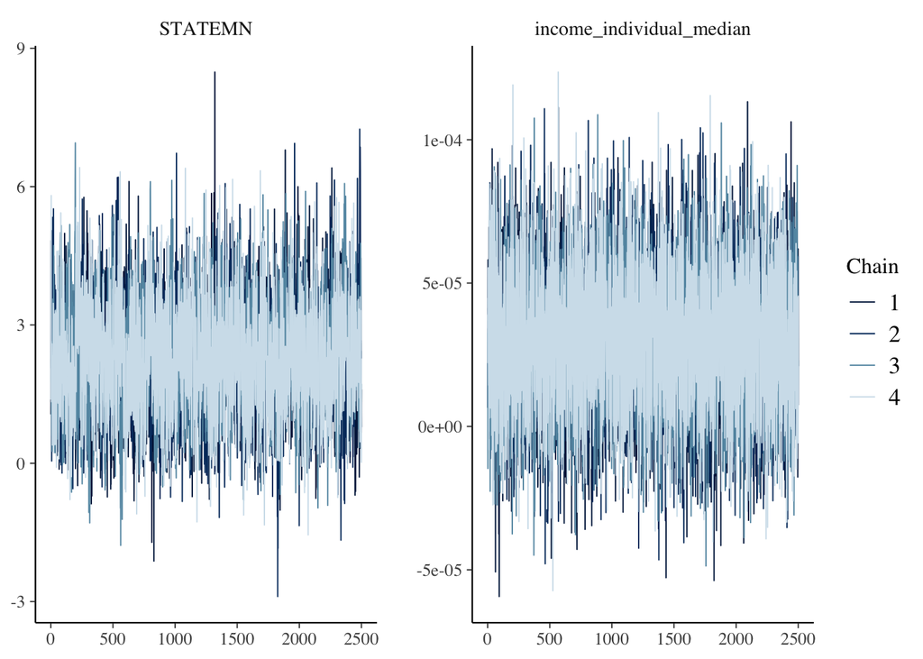

We see that the trace plots are very stable for one of the predictors that was kept in by the model (State Minnesota) and one that was kicked out (income_indivudal_median).

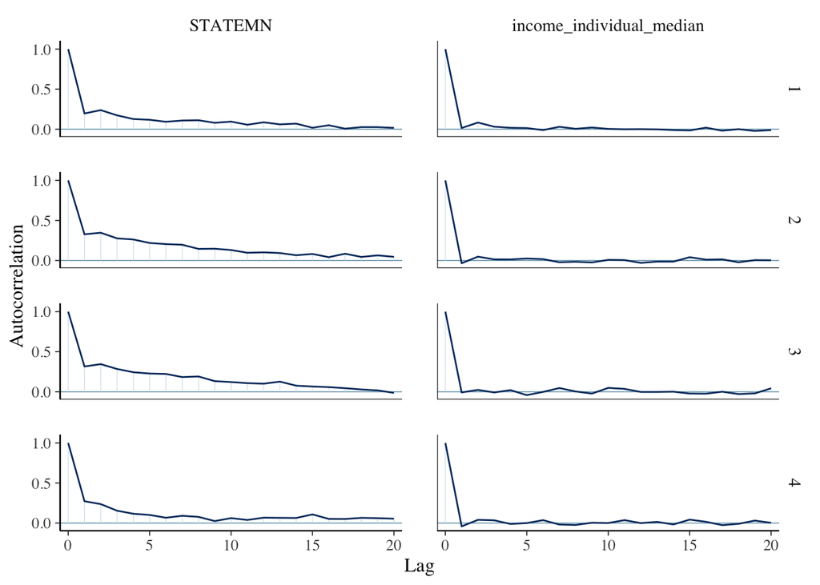

```
## # A tibble: 133 × 5
##    term        estimate std.error   conf.low conf.high
##    <chr>          <dbl>     <dbl>      <dbl>     <dbl>
##  1 (Intercept)    8.09     87.1   -120.        131.
##  2 STATEAR        0.373     0.867   -0.701       1.55
##  3 STATEAZ       -0.308     0.808   -1.36        0.738
##  4 STATECA       -0.139     0.775   -1.14        0.918
##  5 STATECO        1.37      0.873    0.265       2.49
##  6 STATECT        1.25      1.01    -0.00520     2.62
##  7 STATEDC        1.63      1.11     0.216       3.13
##  8 STATEDE        2.04      1.44     0.344       4.14
##  9 STATEFL        0.301     0.707   -0.568       1.26
## 10 STATEGA        0.368     0.694   -0.492       1.32
## # ℹ 123 more rows
```

In general, this tidy plot is a lot to look at but looking through we can see a large amount of estimates that have been sent to very small values, and many predictors have credible interval cross zero Intercept is someone from AL, Asian, midwest, on commercial insurance.

```
## # A tibble: 18 × 6
##    term                         estimate conf.low conf.high     odds  prob
##    <chr>                           <dbl>    <dbl>     <dbl>    <dbl> <dbl>
##  1 STATENV                       -1.25   -2.45     -0.00784 2.88e- 1 0.223
##  2 payer_typeMEDICARE ADVANTAGE  -0.154  -0.280    -0.0300  8.57e- 1 0.461
##  3 age_median                    -0.109  -0.189    -0.0295  8.97e- 1 0.473
##  4 labor_force_participation     -0.0575 -0.0879   -0.0273  9.44e- 1 0.486
##  5 veteran                       -0.0322 -0.0633   -0.00166 9.68e- 1 0.492
##  6 patient_age                    0.0119  0.00845   0.0154  1.01e+ 0 0.503
##  7 race_pacific                   0.822   0.428     1.22    2.27e+ 0 0.695
##  8 STATECO                        1.37    0.265     2.49    3.92e+ 0 0.797
##  9 STATERI                        1.52    0.129     3.05    4.58e+ 0 0.821
## 10 STATEDC                        1.63    0.216     3.13    5.10e+ 0 0.836
## 11 STATEIA                        1.69    0.159     3.37    5.44e+ 0 0.845
## 12 STATEMO                        1.81    0.333     3.41    6.10e+ 0 0.859
## 13 STATEVT                        1.97    0.350     3.69    7.17e+ 0 0.878
## 14 STATENE                        2.02    0.334     3.89    7.56e+ 0 0.883
## 15 STATEDE                        2.04    0.344     4.14    7.70e+ 0 0.885
## 16 STATEMN                        2.19    0.732     3.78    8.98e+ 0 0.900
## 17 STATEID                       75.2    13.0     246.      4.65e+32 1
## 18 DivisionNew England           91.2    14.1     301.      3.89e+39 1
```

We see here that 18 variables whose 80% credible intervals do not cross zero. We see 12 high-level geographical predictors: 11 states, and one division.

We see two variables related to a person, being patient age and payer type Medicare. For each one-year increase in age, that person is 1.011999 times as likely to get a diagnosis within 90 days. This magnitude is minimal but indicates that hospitals may diagnose older patients much. Having Medicare advantage compared to our commercial insurance baseline makes your chance of being diagnosed within 90 days 85.7% as high.

### First digging into our high-level geographical predictors

One of these states Nevada is associated with a decreased chance of getting a diagnosis within 90 days, while Co, Ri, Dc, Ia, MO, Vt, Ne, De, Mn, and ID are all associated with a higher chance of getting a diagnosis holding division, person-related variables, and zip code related variables together.

```
## # A tibble: 10 × 2
##    state total
##    <chr> <int>
##  1 CO      116
##  2 MN       92
##  3 MO       33
##  4 IA       21
##  5 NV       21
##  6 VT       17
##  7 DC       10
##  8 RI        9
##  9 DE        6
## 10 ID        3
```

```
## [1] 113.617
## [1] 42
```

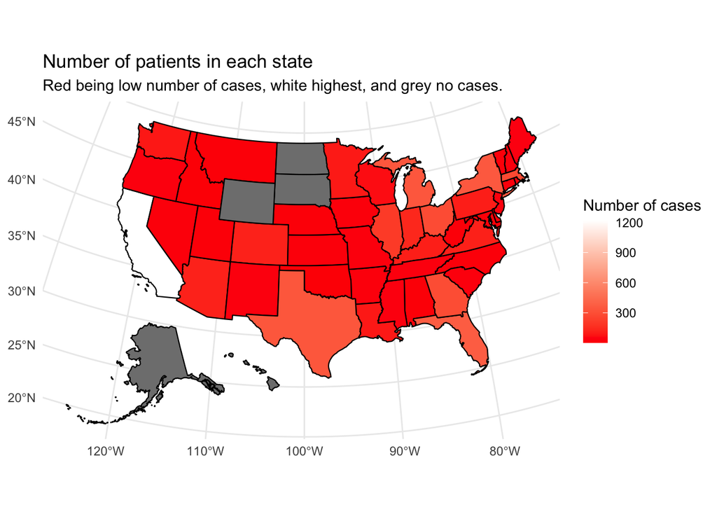

Starting with our state with the highest amount of patients, a patient living in CO as compared to AL is 3.92 times more odds likely to get their diagnosis back within 90 days, holding all other high-level geographical, patient, and zip-code predictors constant. For patients living in MN as compared to AL. is 8.975619 times more odds likely to get their diagnosis back within 90 days, holding all other high-level geographical, patient, and zip-code predictors constant. A patient in our state with the third most cases MO is 6.1 times more odds likely to get their diagnosis back within 90 days, as compared to someone from AL, holding all other high-level geographical, patient, and zip-code predictors constant.

ID has the strongest effect of any state, as a patient living in ID as compared to AL is 4.648387e+32 more odds likely to get their diagnosis back within 90 days, holding all other high-level geographical, patient, and zip-code predictors constant, yet only had 3 patients.

NV, the only state that had a negative correlation meant that a patient’s chance of receiving a diagnosis within 90 days as compared to AL was 0.2876052 as high, holding all other high-level geographical, patient, and zip-code predictors constant.

All other states had a positive correlation to getting a diagnosis back within 90 days, and fewer cases than CO, MN, and MO, holding all other high-level geographical, patient, and zip-code predictors constant.

```
## # A tibble: 1 × 2
##   DiagPeriodL90D total
##            <int> <int>
## 1              1     3
```

```
## # A tibble: 1 × 2
##   Division    total
##   <chr>       <int>
## 1 New England     2
```

Seeing as we have only two cases from New England this is also not nearly enough cases for us to explore the relation.

### Error metrics

```
## $confusion_matrix
##  y   0    1
##  0 373 1618
##  1 348 3001
##
## $accuracy_rates
##
## sensitivity      0.8960884
## specificity      0.1873430
## overall_accuracy 0.6318352
```

We notice an accuracy of 63.2% which is similar Bayesian model we ran showing little difference between the two This model had a sensitivity of 89.6% which means that this model can correctly predict a patient who did get a diagnosis within 90 days 89.6% of the time. However, it had a really poor specificity of 18.7% which means it had a hard time predicting patients who did not receive a diagnosis within 90 days and not getting one within 90 days.

We Did not use any cross-validation, therefore for an outside data set, our model would be expected to perform lower in sensitivity, specificity, and accuracy ratings, so we didn’t use it to save time.

## Final Conclusion

A limitation of our data and analysis is that we could not collect data directly from hospitals; therefore, we could not see if hospital-level factors played a role in breast cancer diagnosis in 90 days.

One weakness of our data is being stuck with only one option for gender in our dataset, separating gender into more expansive roles such as “afab: female,” “amab: trans female” etc. would lead to a more equitable consciousness, and could show disparities in breast cancer diagnosis by gender.

Another limitation is that we are only given a binary yes/no on receiving a diagnosis instead of how many days from the initial visit which could show better trends. Therefore, expanding the complexity of our dependent variable allows us to observe a more dynamic effect of our predictors, potentially uncovering more granular-level distinctions, such as variations in the time taken to receive a diagnosis.

To improve this analysis, someone might include cross-validation when analyzing our models. We could also find a way to predict “NA” values or cases outside of our data set.

In our case it seems that patients living in different states may not have equitable access, for example, a patient living in Nevada’s odds of getting a diagnosis back was 0.2876052 as high as someone in Alabama for a patient of similar personal and zip-code demographics, another patient living in Minnesota is 8.975619 times more odds likely to get their diagnosis back within 90 days as that patient from Alabama show inequity between states.

Insurance plays a big factor in many people’s lives and in our model, someone on Medicare Advantage odds of getting a diagnosis within 90 days is 0.8569726 as high as someone with commercial insurance.

# Code Appendix

```r
#Load packages
library(bayesrules)
library(pROC)
library(tidyr)
library(tidyverse)
library(ggplot2)
library(usmap)
library(sf)
library(rnaturalearth)
library(bayesplot)
library(broom)
library(broom.mixed)
library(glmnet)
library(rstan)
library(rstanarm)
library(plotly)
library(usethis)
```

```r
# Set a more color blind friendly palette
palette("Okabe-Ito")
scale_colour_discrete <- function(...) scale_colour_manual(values = palette())
scale_fill_discrete   <- function(...) scale_fill_manual(values = palette())
```

### Load and Clean Data

```r
# Load the data
patient_data<-read.csv("Data/training.csv")
hospital_data<- read.csv("Data/Hospitals.csv")
population_data <- read.csv("Data/nst-est2019-alldata.csv")
population_data <- population_data %>%
  select(NAME, POPESTIMATE2018) %>%
  filter(NAME != c("United States", "Northeast Region", "Midwest Region", "South Region", "West Region"))
```

```r
hospital_data_zip <- hospital_data %>%
  mutate(patient_zip3=substr(hospital_data$ZIP, 1,3))
hospital_data_zip$patient_zip3 <- strtoi(hospital_data_zip$patient_zip3)
```

```r
combined_data <- left_join(hospital_data_zip, patient_data, by = "patient_zip3", relationship = "many-to-many")
```

```r
length(unique(patient_data$patient_id))
length(unique(combined_data$patient_id))
```

```r
combined_data_hs <- combined_data %>%
  group_by(patient_id) %>%
  mutate(total_hospitals = n()) %>%
  distinct(patient_id, .keep_all = TRUE)
```

```r
combined_data_hs_clean <- combined_data_hs %>%
  ungroup() %>%
  select(-c(X,Y,OBJECTID,ID,NAME,ADDRESS,CITY,ZIP,ZIP4,TELEPHONE,TYPE,STATUS,TRAUMA,POPULATION,COUNTY,COUNTRY,COUNTYFIPS,LATITUDE,LONGITUDE,NAICS_CODE,NAICS_DESC,SOURCE,SOURCEDATE,VAL_METHOD,VAL_DATE,WEBSITE,STATE_ID,ALT_NAME,ST_FIPS,OWNER,TTL_STAFF,BEDS,TRAUMA,HELIPAD,patient_state,patient_zip3,patient_gender,breast_cancer_diagnosis_code,breast_cancer_diagnosis_desc,metastatic_cancer_diagnosis_code,metastatic_first_novel_treatment,metastatic_first_novel_treatment_type,patient_id,bmi))
```

```r
combined_data_hs_clean$Ozone <- as.numeric(combined_data_hs_clean$Ozone)
combined_data_hs_clean$PM25 <- as.numeric(combined_data_hs_clean$PM25)
combined_data_hs_clean$N02 <- as.numeric(combined_data_hs_clean$N02)
```

```r
combined_data_hs_clean <- na.omit(combined_data_hs_clean)
```

```r
# Adding population to the data
state_abbreviations <- data.frame(
  full_name = c("Alabama", "Alaska", "Arizona", "Arkansas", "California", "Colorado", "Connecticut",
                "Delaware", "District of Columbia", "Florida", "Georgia", "Hawaii", "Idaho", "Illinois",
                "Indiana", "Iowa", "Kansas", "Kentucky", "Louisiana", "Maine", "Maryland", "Massachusetts",
                "Michigan", "Minnesota", "Mississippi", "Missouri", "Montana", "Nebraska", "Nevada",
                "New Hampshire", "New Jersey", "New Mexico", "New York", "North Carolina", "North Dakota",
                "Ohio", "Oklahoma", "Oregon", "Pennsylvania", "Rhode Island", "South Carolina", "South Dakota",
                "Tennessee", "Texas", "Utah", "Vermont", "Virginia", "Washington", "West Virginia",
                "Wisconsin", "Wyoming", "Puerto Rico"),
  abbreviation = c("AL", "AK", "AZ", "AR", "CA", "CO", "CT", "DE", "DC", "FL", "GA", "HI", "ID", "IL",
                   "IN", "IA", "KS", "KY", "LA", "ME", "MD", "MA", "MI", "MN", "MS", "MO", "MT", "NE",
                   "NV", "NH", "NJ", "NM", "NY", "NC", "ND", "OH", "OK", "OR", "PA", "RI", "SC", "SD",
                   "TN", "TX", "UT", "VT", "VA", "WA", "WV", "WI", "WY", "PR")
)
```

```r
population_data_abv <- population_data %>%
  left_join(state_abbreviations, by = c("NAME" = "full_name")) %>%
  mutate(STATE = coalesce(abbreviation, "Unknown")) # If the abbreviation is missing, mark it as "Unknown"
```

### Data Visualizations

```r
combined_data_clean1 <- left_join(combined_data_hs_clean, population_data_abv, by = "STATE") %>%
  select(-c(NAME, abbreviation))

total_hospitals <- hospital_data %>%
  group_by(STATE) %>%
  summarise(total_hospitals = n()) %>%
  arrange(desc(total_hospitals))

full_dataset<-left_join(combined_data_clean1, total_hospitals, by = "STATE")

full_dataset$POPESTIMATE2018 <- as.numeric(full_dataset$POPESTIMATE2018)
full_dataset$total_hospitals.y <- as.numeric(full_dataset$total_hospitals.y)

hospital_data_per_state <- full_dataset %>%
  mutate(
    ppl_per_hos = POPESTIMATE2018 / total_hospitals.y
  ) %>%
  select(STATE, ppl_per_hos) %>%
  group_by(STATE) %>%
  summarize(ppl_per_hos = mean(ppl_per_hos, na.rm = TRUE)) %>%
  filter(!STATE %in% c("AS", "GU", "MP", "PW", "VI"))
```

```r
full_dataset %>%
  count(STATE) %>%
  arrange(desc(n)) %>%
  ggplot(aes(x = reorder(STATE, n), y = n)) +
  geom_bar(stat = "identity") +
  theme(
    plot.title = element_text(size = 20),  # Adjust the title size
    axis.title.x = element_text(size = 16),  # Adjust x-axis label size
    axis.title.y = element_text(size = 16),  # Adjust y-axis label size
    axis.text.x = element_text(size = 15),  # Adjust x-axis tick label size
    axis.text.y = element_text(size = 8),  # Adjust y-axis tick label size
    legend.text = element_text(size = 14)  # Adjust legend text size
  ) +
  theme_minimal() +  # You can use a different theme if you prefer
  theme(
    plot.background = element_rect(fill = "white"),  # Set plot background color
    panel.grid.major = element_line(color = "lightgray"),  # Adjust major gridlines
    panel.grid.minor = element_blank()  # Remove minor gridlines
  ) +
  labs(
    title = "Cases per State in the Data Set",
    x = "State",
    y = "Cases"
  ) +
  coord_flip()
```

```r
# Hospitals by State
  ggplot(hospital_data_per_state, aes(x = reorder(STATE, ppl_per_hos), y = ppl_per_hos)) +
  geom_bar(stat = "identity") +
  theme(
    plot.title = element_text(size = 20),  # Adjust the title size
    axis.title.x = element_text(size = 16),  # Adjust x-axis label size
    axis.title.y = element_text(size = 16),  # Adjust y-axis label size
    axis.text.x = element_text(size = 15),  # Adjust x-axis tick label size
    axis.text.y = element_text(size = 8),  # Adjust y-axis tick label size
    legend.text = element_text(size = 14)  # Adjust legend text size
  ) +
  theme_minimal() +  # You can use a different theme if you prefer
  theme(
    plot.background = element_rect(fill = "white"),  # Set plot background color
    panel.grid.major = element_line(color = "lightgray"),  # Adjust major gridlines
    panel.grid.minor = element_blank()  # Remove minor gridlines
  ) +
  labs(
    title = "People per Hospitals by State",
    x = "State",
    y = "People per Hospital"
  ) +
  coord_flip()
```

```r
# Map of US States by percentage of people who are diagnosised within 90 days
hospital_data_per_state1 <- rename(combined_data_hs, state = STATE) %>%
  group_by(state) %>%
  filter(DiagPeriodL90D != "n/a") %>%
  summarise(percent_diag = mean(DiagPeriodL90D))


MapOfStatesTotalHospitals <- plot_usmap(data = hospital_data_per_state1, values = "percent_diag", region = "state") +
  labs(title = "US States by percentage of people who are diagnosised within 90 days",
       subtitle = "White being the lowest and blue being the highest") +
  scale_fill_continuous(low = "white",high = "blue", name = "Percentage of diagnoises within 90 days") +
  theme_minimal()

MapOfStatesTotalHospitals
```

```r
# Plot of Percentage of Payer Types within Diagnosis
health_data_perc <- patient_data %>%
  filter(!is.na(payer_type) & payer_type != "") %>%
  filter(!is.na(DiagPeriodL90D) & DiagPeriodL90D != "") %>%
  group_by(DiagPeriodL90D, payer_type) %>%
  summarise(count = n()) %>%
  mutate(percentage = count / sum(count) * 100)

health_data_perc %>%
  ggplot(aes(x = as.factor(DiagPeriodL90D), y = percentage, fill = payer_type)) +
  geom_bar(stat = "identity", position = "dodge", width = 0.7) +
  geom_text(aes(label = paste0(round(percentage), "%")), position = position_dodge(width = 0.7), vjust = -0.5) +
  labs(x = "Diagnosis", y = "Percentage", title = "Percentage of Payer Types within Diagnosis", fill = "Payer Type") +
  theme_minimal()
```

```r
#Diagnosed within 90 days by race
diag_race<-patient_data %>%
  filter(!is.na(patient_race) & patient_race != "") %>%
  filter(!is.na(DiagPeriodL90D) & DiagPeriodL90D != "") %>%
  group_by(patient_race) %>%
  summarise(avg_diag_90 = mean(DiagPeriodL90D))

ggplot(diag_race, aes(x=patient_race, y=avg_diag_90))+
  geom_point()+
  labs(x="Patient Race", y="Average Diagnosed Under 90 Days", title = "Diagnosed Under 90 Days by Race")+
  theme_minimal()
```

```r
# Access to Hospitals per State by Average Diagnosis Within 90 Days
full_dataset12<-full_dataset %>%
  count(STATE)

left_join(full_dataset, full_dataset12, by = "STATE") %>%
  mutate(
    ppl_per_hos = POPESTIMATE2018 / total_hospitals.y) %>%
  filter(!is.na(DiagPeriodL90D) & DiagPeriodL90D != "") %>%
  group_by(STATE, ppl_per_hos) %>%
  summarise(avg_diag_90 = mean(DiagPeriodL90D), num_cases = n()) %>%
  arrange(desc(avg_diag_90)) %>%
  ggplot()+
  geom_text(aes(x=ppl_per_hos, y=avg_diag_90, label = STATE, color = num_cases))+
  labs(x= "People per Hospital", y="Average Diagnosis Within 90 Days", title = "Access to Hospitals per State by Average Diagnosis Within 90 Days")+
  scale_color_continuous(name = "Number of Cases") +
  theme_minimal()
```

```r
# Age Density over Breast Cancer Diagnosis
full_dataset %>%
  filter(!is.na(DiagPeriodL90D)) %>%
  mutate(DiagPeriodL90D = factor(DiagPeriodL90D, labels = c("False", "True"))) %>%
  ggplot(aes(x = patient_age, fill = as.factor(DiagPeriodL90D)))+
  geom_density()+
  labs(title = "Age Density over Breast Cancer Diagnosis",
       x = "Age",
       y = "Density",
       fill = "Diagnosis within 90 Days")+
  theme_minimal()
```

# Methodology

### Preliminary Analysis

```r
# Clean code
patient_data_clean <- patient_data%>%
  select(DiagPeriodL90D,
         patient_race,
         patient_state,
         patient_age,
         payer_type)

patient_data_clean <- patient_data_clean %>%
  mutate(patient_race = ifelse(patient_race == "", NA, patient_race),
         payer_type = ifelse(payer_type == "", NA, payer_type),
         patient_state = ifelse(patient_state == "", NA, patient_state))

patient_data_clean <- na.omit(patient_data_clean)
```

##Please do not run this model, and instead download “diag_post3.rds” from our GitHub as this model takes ~30 minutes to run

```r
# Model
diag_post3 <- stan_glm(
 DiagPeriodL90D  ~ patient_race + patient_state + patient_age + payer_type,
  family = binomial,
  prior_PD = FALSE,
  data = patient_data_clean,
  chains = 4, iter = 5000*2, seed = 84735, refresh = 0)

saveRDS(diag_post3,"~/Desktop/diag_post3.rds")
```

```r
diag_post3 <- readRDS("diag_post3.rds")
```

```r
pp_check(diag_post3)
```

```r
mcmc_trace(diag_post3, pars = vars(contains("patient_race")))
mcmc_trace(diag_post3, pars = vars(contains("type")))
```

```r
mcmc_acf(diag_post3, pars = vars(contains("patient_race")))
mcmc_acf(diag_post3, pars = vars(contains("type")))
```

### Error Metrics

```r
classification_summary(diag_post3, patient_data_clean, cutoff = 0.5)
```

### Analysis

```r
tidy_simple <- tidy(diag_post3, conf.int = 0.9, conf.level = 0.9)
(tidy_simple)
```

```r
exp(0.04737589) #if you are white compared to Asian
exp(-0.04866796) #if you are black compared to Asian

exp(-0.03114499) #if you have Medicaid compared to private
exp(-0.17528198) #if you have Medicare compared to private
```

## Laplace Model

### Laplace Analysis

```r
combined_data_hs_clean <- combined_data_hs %>%
  ungroup() %>%
  select(-c(X,Y,OBJECTID,ID,NAME,ADDRESS,CITY,ZIP,ZIP4,TELEPHONE,TYPE,STATUS,TRAUMA,POPULATION,COUNTY,COUNTRY,COUNTYFIPS,LATITUDE,LONGITUDE,NAICS_CODE,NAICS_DESC,SOURCE,SOURCEDATE,VAL_METHOD,VAL_DATE,WEBSITE,STATE_ID,ALT_NAME,ST_FIPS,OWNER,TTL_STAFF,BEDS,TRAUMA,HELIPAD,patient_state,patient_zip3,patient_gender,breast_cancer_diagnosis_code,breast_cancer_diagnosis_desc,metastatic_cancer_diagnosis_code,metastatic_first_novel_treatment,metastatic_first_novel_treatment_type,patient_id,bmi))
```

```r
combined_data_hs_clean$Ozone <- as.numeric(combined_data_hs_clean$Ozone)
combined_data_hs_clean$PM25 <- as.numeric(combined_data_hs_clean$PM25)
combined_data_hs_clean$N02 <- as.numeric(combined_data_hs_clean$N02)
```

```r
combined_data_hs_clean[combined_data_hs_clean == ""] <- NA
```

```r
combined_data_hs_clean <- na.omit(combined_data_hs_clean)
```

```r
#Do not run code below, instead make sure to download "laplace_modelreal.rds" from our github to your machine, as this model takes 3+ hours to run!

laplace_model <- stan_glm(DiagPeriodL90D ~.,
                        data = combined_data_hs_clean,
                        family = binomial,
                        prior = laplace(autoscale = TRUE),
                        chains = 4,iter = 2500*2, cores = 2)
saveRDS(laplace_model,"~/Desktop/laplace_modelreal.rds")
```

```r
laplace_mod <- readRDS("~/Desktop/laplace_modelreal.rds")
```

```r
pp_check(laplace_mod)
```

```r
mcmc_trace(laplace_mod, pars = "STATEMN", "income_individual_median")
```

```r
mcmc_acf(laplace_mod, pars = "STATEMN", "income_individual_median")
```

```r
tidyLaPlace <- tidy(laplace_mod, conf.int = 0.80, conf.level = 0.80)
(tidyLaPlace)
```

```r
tidyLaPlace_meaningful <- tidyLaPlace %>%
  filter(!(conf.low < 0 & conf.high > 0))
tidyLaPlace_meaningful <-tidyLaPlace_meaningful %>%
  select(term,estimate,conf.low,conf.high) %>%
  mutate(odds = exp(estimate)) %>%
  mutate(prob = odds/(odds+1)) %>%
  arrange(estimate)
tidyLaPlace_meaningful
```

### First digging into our high-level geopgraphical predictors

```r
tidy_mapdata <- combined_data_hs_clean %>%
  mutate(state = STATE) %>%
  select(state) %>%
  filter(state == "CO" | state == "DC" | state =="RI" | state == "NV" | state == "MN"| state =="IA" | state == "MO" | state == "VT" | state =="DE" | state == "ID") %>%
  group_by(state) %>%
  summarise(total = n())
tidy_mapdata %>%
  arrange(desc(total))
```

```r
patients_in_data <- combined_data_hs_clean %>%
  mutate(state = STATE) %>%
  group_by(state) %>%
  summarise(total = n())
mean(patients_in_data$total)
median(patients_in_data$total)
```

```r
MapOfTidyStates <- plot_usmap(data = patients_in_data, values = "total", region = "state") +
  labs(title = "Number of patients in each state",
       subtitle = "Red being low number of cases, white highest, and grey no cases.") +
  scale_fill_continuous(low = "red",high = "white", name = "Number of cases") +
  theme_minimal()

MapOfTidyStates
```

```r
combined_data_hs_clean %>%
       filter(STATE == "ID") %>%
       group_by(DiagPeriodL90D) %>%
       summarise(total=n())
```

```r
state_division <- (combined_data_hs_clean) %>%
  group_by(Division) %>%
  filter(DiagPeriodL90D != "n/a") %>%
  summarise(total = n())
  state_division %>%
    filter(Division == "New England")
```

### Error metrics

```r
set.seed(43576)
classification_summary(laplace_mod, combined_data_hs_clean, cutoff = 0.54)
```